# Data Visualisation project

2023-05-04

# Background

Both body image and body schema, when corrupted, have pronounced psychological and physical effects. Body image refers to conscious perceptions of our body and the way we believe we look *(Cash et al., 2002)*. It is, in essence, our self-image and the opinions we hold regarding the way we believe other people view us. By contrast, Body schema is considered to lay within the unconscious sphere of our understanding, with *Haggard and Wolpert (2005)* defining it as “a central representation of the positions of body parts in space, which is updated during body movement” and includes the arrangements of limbs, the configuration of these in space as well as the shape of the body. Much of the pre-existing literature alludes to a relationship or form of interplay between body image **(BI)** and body schema **(BS)**. However, the exact nature of this relationship lacks a conclusive definition or inclusive research. In fact, much of the existing literature fails to include male participants, leaving the unexplored question of how gender may impact on the BI-BS relationship.

## Data origins

The raw data for this project was collected during my undergraduate dissertation project. Body image (BI) scores are based on Likert-scale responses to the *Body Appreciation Scale-2 Questionnaire*. Responses to each question were summed to create a final score for each participant in which 10= negative body issue whilst 50= positive body image.

## Research Question and Rationale

The rationale for this project was to both provide a visualization of the data I collected during my undergraduate project, as well as to explore the data in a slightly different way. The original project aimed to look at gender as a moderator of the relationship whilst in this project I aim to look at trends more generally. Although I understand the data already in terms of knowing gender does not *moderate* the relationship, the data suggested there were gender differences. I want to explore these further and answer the question of what are the gender differences in the relationship between body image and body schema.

# Setup of the project

**Firstly, the libraries that were to be used for this project are loaded in and installed if not already.**

```r
# Load libraries that the project will use
library(here)
library(tidyverse)
library(RColorBrewer)
library(readr)
library(ggplot2)
```

**Then the data is loaded into R and assigned to a data frame.**

```r
# Use library(here) to import the data and assign it to a data frame
# Importing the data from Github and setting it as a data frame
df <- read.csv("https://raw.githubusercontent.com/hannahcsx/PSY6422_Project/main/project_data.csv")
```

```r
# Check data frame
head(df)
```

|  | BS | BI | Gender |
| --- | --- | --- | --- |
| 1 | 28 | 12.0 | 1 |
| 2 | 42 | 12.0 | 1 |
| 3 | 36 | 16.0 | 2 |
| 4 | 27 | 12.5 | 1 |
| 5 | 30 | 13.5 | 2 |
| 6 | 28 | 12.0 | 1 |

# Preparing the data for visualization

**An extra variable is used and Gender is converted from 1&2 to Males & Female**

```r
# Converting the data we have, currently gender is represented as 1 for male and 2 for female so we need to change this so we'll use a new variable
# Find the average of the data we're using so we'll need another variable for later
df$Gender_converted <- ifelse(df$Gender ==1, "male", "female")
avg_bs <- mean(df$BS)
avg_bi <- mean(df$BI)
```

### Male Data Summary:

[output not shown]

### Female Data Summary:

[output not shown]

# Visualizing the data

**The following creates a Scatter plot with a line of best fit**

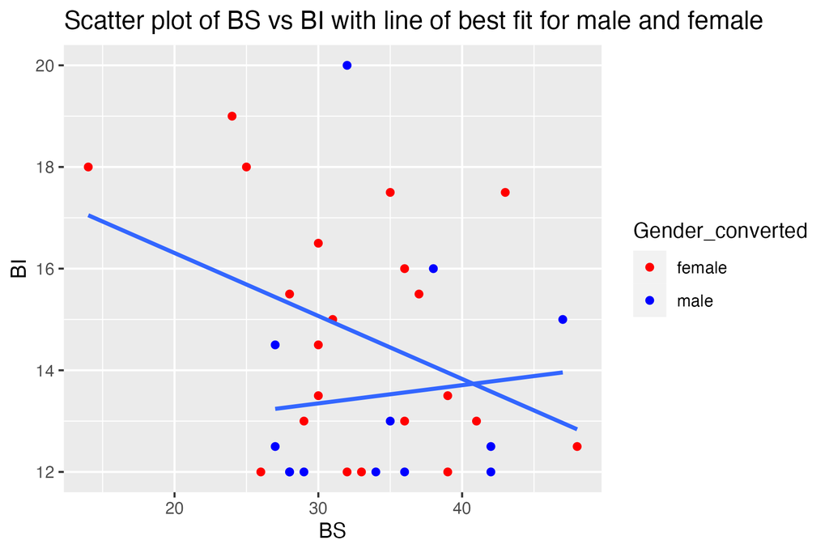

```r
# Using ggplot to create a Scatter Plot with BS vs BI
p0 <- ggplot(df,aes(x=BS,y=BI,group=Gender_converted))+
        ggtitle("Scatter plot of BS vs BI with line of best fit for male and female")+
        geom_point(aes(color=Gender_converted))+
        scale_color_manual(values=c('Red','Blue'))+
        geom_smooth(method = "lm", se = FALSE)

#Save image
ggsave("BS_BIScatterPlot.png", plot =p0, width=6, height=4, dpi=300)
```

A scatter-plot was chosen to see the overall spread of data, as well as which data points were male and female. This, along with lines of best fit allows us to see the correlation between BI and BS for both male and female and reveals vastly different trends for both. It also allows us to see how these trends vary from averages. However, Although this graph reveals different correlational relationships between male and female participants, it does not as easily show how scores on each conditions varied and thus histograms were needed.

**The following creates a histograms with a line of mean average**

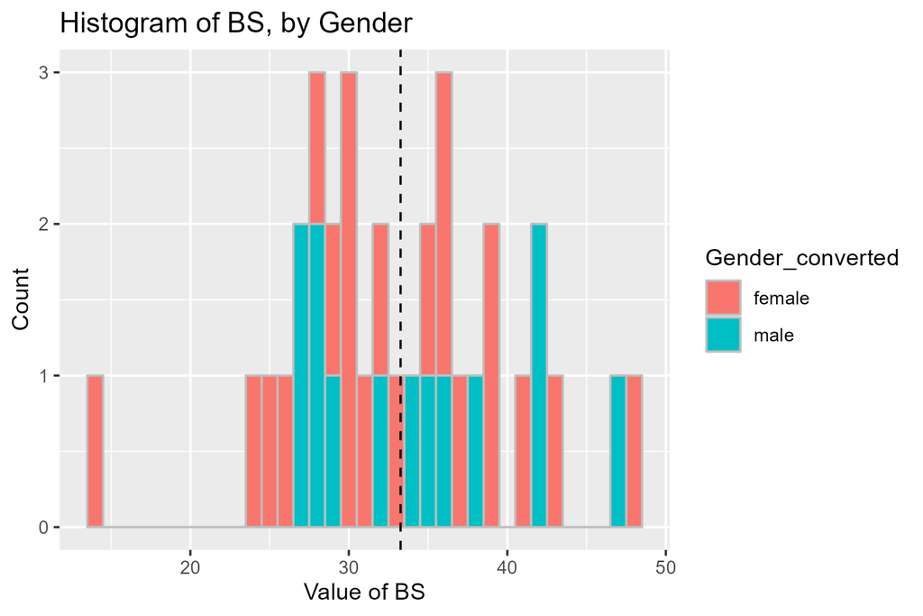

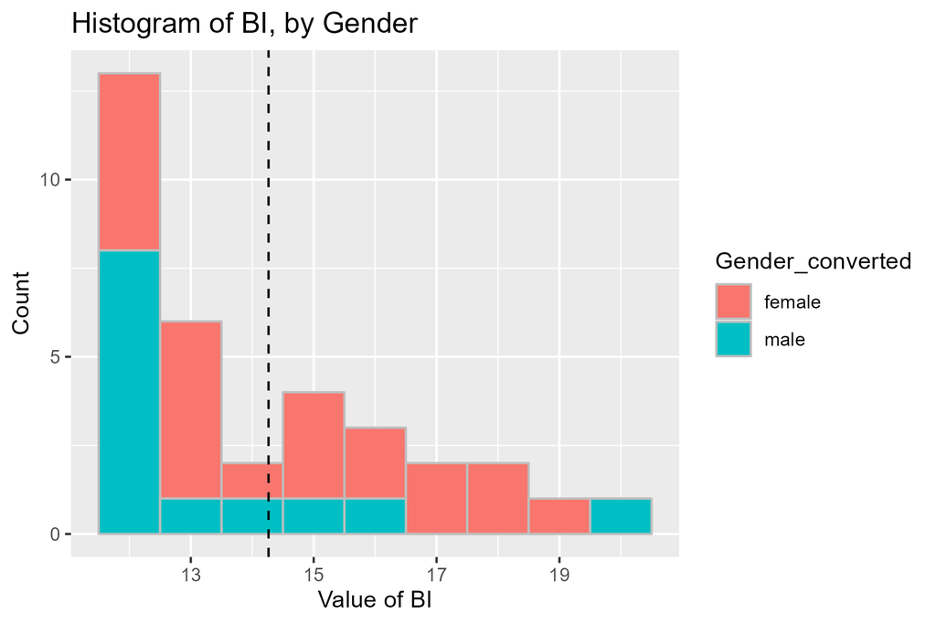

```r
# Using ggplot to create a Histogram with male and female BS scores with a mean line

p1 <- ggplot(df, aes(x = BS, fill = Gender_converted)) +
        geom_histogram(binwidth = 1, color="grey") +
        geom_vline(xintercept = avg_bs, color="black", linetype="dashed")+
        ggtitle("Histogram of BS, by Gender") +
        xlab("Value of BS") +
        ylab("Count")

#Save image
ggsave("BSHistogramWithMeanLine.png", plot =p1, width=6, height=4, dpi=300)

# Same as above but using BI instead

p2 <- ggplot(df, aes(x = BI, fill = Gender_converted)) +
        geom_histogram(binwidth = 1, color="grey") +
        geom_vline(xintercept = avg_bi, color="black", linetype="dashed")+
        ggtitle("Histogram of BI, by Gender") +
        xlab("Value of BI") +
        ylab("Count")

#Save image
ggsave("BIHistogramWithMeanLine.png", plot =p2, width=6, height=4, dpi=300)
```

The Histograms reveal much clearer differences between male and female participants in terms of scores on each conditions.

# Discussion

## Limitations and future directions

Although these visualization reveal that there are gender differences in both body image, body schema, and the relationship between the both, it does not reveal if these would be statistically significant, which could be seen as a limitation. Although there are score differences, if these are not found to have any statistical value then the differences *seemingly* caused by gender can be discounted. However, the visualization may provide rationale for further statistical analysis or research.

The repository for this project including the markdown file, raw data, code-book and other files) is available online via github.

### References

Cash, TF., Fleming, EC., Alindogan, J., Steadman, L. & Whitehead, A. (2002). Beyong body image as a trait: the development and validation of the Body Image States Scale. *Eat Discord*, 10(2), pp 103-113.

Haggard P., Wolpert D. (2005). *“Disorders of body schema,”* in High-Order Motor Disorders: From Neuroanatomy and Neurobiology to Clinical Neurology, eds Freund J., Jeannerod M., Hallett M., Leiguarda R. (Oxford: Oxford University Press), 261–271.